# MSD Analytic Questions

Allison Towey

2024-09-18

```r
data <- read_psd("~/Github/training_day/Data/MER_Structured_TRAINING_Datasets_PSNU_IM_FY59-62_20240816_v1_1.zip")
```

## 1: Which partner should we focus on with lower target achievement in test positivity for the year?

When we take a look at prime partners’ `HTS_TST_POS` reported versus their targets for the current year (`FY2061`), we see the following:

```r
# Filter to the current year (2061)
filtered_data_q1 <- data %>%
  filter(fiscal_year == 2061, indicator == "HTS_TST_POS", standardizeddisaggregate=="Total Numerator")

# Find reported HTS_TST_POS versus targets
summary_table_q1 <- filtered_data_q1 %>%
  group_by(prime_partner_name) %>%
  summarise(
    PSNUs = paste(unique(psnu), collapse = ", "),
    targets = sum(targets, na.rm = TRUE),
    cumulative = sum(cumulative, na.rm = TRUE),
  ) %>%
  ungroup() %>%
  calc_achievement() %>%
  #adorn_achievement()
  arrange(desc(achievement)) %>%
  mutate(achievement = ifelse(is.na(achievement), "No targets", paste0(achievement*100, "%")))
```

**`FY2061` (through `Q3`) Achievement of `HTS_TST_POS` Targets by Prime Partner**

```
## # A tibble: 15 × 5
##    prime_partner_name PSNUs                       targets cumulative achievement
##    <chr>              <chr>                         <dbl>      <dbl> <chr>
##  1 Chiefs             Great Lakes, Wisconsin           23         41 178%
##  2 Quakes             Eugene, Spokane, Vancouver…     525        847 161%
##  3 Lugnuts            Oklahoma City                   128        167 130%
##  4 Wind Surge         Albuquerque                     263        326 124%
##  5 Crawdads           Peoria, Quad Cities             629        765 122%
##  6 Blue Wahoos        Hillsboro, Eugene               889       1059 119%
##  7 Cubs               Wisconsin                       640        755 118%
##  8 Aces               Spokane, Vancouver             1066       1161 109%
##  9 Captains           Peoria, Great Lakes, Quad …     221        215 97%
## 10 Travelers          Great Lakes                     399        385 96%
## 11 Cardinals          Quad Cities                      28         14 50%
## 12 Dash               Salt Lake, Sugar Land           568        172 30%
## 13 Jumbo Shrimp       South Atlantic                    0        190 No targets
## 14 Pelicans           South Atlantic                    0        115 No targets
## 15 SeaWolves          Albuquerque, Sugar Land           0         29 No targets
```

```r
# Do the same for 2060 data
filtered_data_2060 <- data %>%
  filter(fiscal_year == 2060, indicator == "HTS_TST_POS", standardizeddisaggregate=="Total Numerator")

# Find reported HTS_TST_POS versus targets
summary_table_2060 <- filtered_data_2060 %>%
  group_by(prime_partner_name) %>%
  summarise(
    PSNUs = paste(unique(psnu), collapse = ", "),
    targets = sum(targets, na.rm = TRUE),
    cumulative = sum(cumulative, na.rm = TRUE),
  ) %>%
  ungroup() %>%
  calc_achievement() %>%
  #adorn_achievement()
  arrange(desc(achievement)) %>%
  mutate(achievement = ifelse(is.na(achievement), "No targets", paste0(achievement*100, "%")))
```

**`FY2060` Achievement of `HTS_TST_POS` Targets by Prime Partner**

```
## # A tibble: 17 × 5
##    prime_partner_name PSNUs                       targets cumulative achievement
##    <chr>              <chr>                         <dbl>      <dbl> <chr>
##  1 Captains           Great Lakes, Peoria, Quad …     119        245 206%
##  2 River Bandits      Hillsboro, Eugene               529        847 160%
##  3 Quakes             Vancouver, Eugene, Spokane…     971       1435 148%
##  4 Chiefs             Wisconsin, Great Lakes           41         54 132%
##  5 Aces               Vancouver, Spokane             1386       1688 122%
##  6 Crawdads           Peoria, Quad Cities            1015       1115 110%
##  7 Travelers          Great Lakes                     633        615 97%
##  8 Cubs               Wisconsin                      1311       1186 90%
##  9 Pelicans           South Atlantic                  462        371 80%
## 10 Wind Surge         Albuquerque                     140        108 77%
## 11 Blue Wahoos        Eugene, Hillsboro               814        558 69%
## 12 Stripers           Albuquerque                     418        237 57%
## 13 Dash               Sugar Land, Salt Lake           353        198 56%
## 14 Cardinals          Quad Cities                     277         38 14%
## 15 Red Sox            Oklahoma City                    30          0 0%
## 16 Lugnuts            Oklahoma City                     0        201 No targets
## 17 SeaWolves          Albuquerque, Sugar Land           0         22 No targets
```

To understand where the `Dash`’s issues may be, we can also take a look at which PSNUs they are operating in. `Dash` appears to be closer to its targets in the `Salt Lake` PSNU than the `Sugar Land` PSNU:

```r
summary_table_DASH <- data %>%
  filter(fiscal_year == 2061, indicator == "HTS_TST_POS", standardizeddisaggregate=="Total Numerator", prime_partner_name=="Dash")%>%
  group_by(psnu) %>%
  summarise(
    targets = sum(targets, na.rm = TRUE),
    cumulative = sum(cumulative, na.rm = TRUE),
  ) %>%
  ungroup() %>%
  calc_achievement() %>%
  #adorn_achievement()
  arrange(desc(achievement)) %>%
  mutate(achievement = ifelse(is.na(achievement), "No targets", paste0(achievement*100, "%")))
```

```
## # A tibble: 2 × 4
##   psnu       targets cumulative achievement
##   <chr>        <dbl>      <dbl> <chr>
## 1 Salt Lake      109         70 64%
## 2 Sugar Land     459        102 22%
```

Zooming out, we also will want to consider both the percentage of target achievement and the scale of the operation.

- For example, if Partner A has a target of 20 and reports 10, they have a 50% achievement rate. While this seems significant, the overall impact is relatively small due to the low target number.
- In contrast, Partner B has a target of 10,000 and reports 6,000, resulting in a 60% achievement rate. Although this rate is higher than Partner A’s, the absolute gap in performance is much larger. The magnitude of the shortfall for Partner B is much more substantial.

We can normalize performance based on the size of the operation to ensure that we direct resources effectively. By min-max scaling our targets and cumulative scores across partners, I created a simple composite score equation:

$$\text{Partner Composite Score} = (\text{Normalized Target} +
\text{Normalized Cumulative}) \times (1 - \text{Achievement Ratio})$$

This formula combines the scaled values of targets and cumulative results with the inverse of the achievement ratio, where higher composite scores (indicating worse performance) are driven by high normalized targets and cumulative results paired with a low achievement ratio. This method allows us to identify partners with significant operational scope who are underperforming, helping prioritize interventions and allocate resources efficiently.

```r
# Grab min and maxes for targets and cumulative HTS_TST_POS
min_targets <- min(summary_table_q1$targets[summary_table_q1$targets > 0], na.rm = TRUE)
max_targets <- max(summary_table_q1$targets[summary_table_q1$targets > 0], na.rm = TRUE)
min_cumulative <- min(summary_table_q1$cumulative[summary_table_q1$cumulative > 0], na.rm = TRUE)
max_cumulative <- max(summary_table_q1$cumulative[summary_table_q1$cumulative > 0], na.rm = TRUE)

# Normalization function
normalize <- function(value, min_value, max_value) {
  (value - min_value) / (max_value - min_value)
}

# Normalize the table and calculate the score
normalized_summary_table_q1 <- summary_table_q1 %>%
  mutate(
    normalized_targets = normalize(targets, min_targets, max_targets),
    normalized_cumulative = normalize(cumulative, min_cumulative, max_cumulative)
  ) %>%
  calc_achievement() %>%
  mutate(
    score = (normalized_targets + normalized_cumulative) * (1 - achievement)*10
  ) %>%
  arrange(desc(score))
```

```
## # A tibble: 15 × 8
##    prime_partner_name PSNUs    targets cumulative achievement normalized_targets
##    <chr>              <chr>      <dbl>      <dbl>       <dbl>              <dbl>
##  1 Dash               Salt La…     568        172        0.3             0.523
##  2 Travelers          Great L…     399        385        0.96            0.360
##  3 Captains           Peoria,…     221        215        0.97            0.190
##  4 Cardinals          Quad Ci…      28         14        0.5             0.00479
##  5 Chiefs             Great L…      23         41        1.78            0
##  6 Lugnuts            Oklahom…     128        167        1.3             0.101
##  7 Wind Surge         Albuque…     263        326        1.24            0.230
##  8 Aces               Spokane…    1066       1161        1.09            1
##  9 Cubs               Wiscons…     640        755        1.18            0.592
## 10 Crawdads           Peoria,…     629        765        1.22            0.581
## 11 Blue Wahoos        Hillsbo…     889       1059        1.19            0.830
## 12 Quakes             Eugene,…     525        847        1.61            0.481
## 13 Jumbo Shrimp       South A…       0        190       NA              -0.0221
## 14 Pelicans           South A…       0        115       NA              -0.0221
## 15 SeaWolves          Albuque…       0         29       NA              -0.0221
## # ℹ 2 more variables: normalized_cumulative <dbl>, score <dbl>
```

In this instance, it still looks like we should prioritize **`Dash`** given `FY2061` data, as they have the highest composite score. This indicates that although their normalized targets and cumulative results are relatively high, their achievement ratio is low, suggesting room for improvement.

#### **Question: Is this normalization method commonly used, and should I have applied it in this instance? It felt like just going off of percentage was not taking into account scale. Would love to know more here.**

## 2. What share of total and positive tests are from index testing in the latest quarter?

To answer this question, we can look at modality disaggregation for `HTS_TST` and `HTS_TST_POS`.

```r
# Pivot the table into longer format
data_long <- data %>%
  pivot_longer(
    cols = starts_with("qtr"),
    names_to = "quarter", # New column for the quarter
    values_to = "value" # New column for the values
  ) %>%
  filter(!is.na(value)) %>%
  mutate(
    quarter = gsub("qtr", "", quarter) # Remove "qtr" from quarter names (now in integer format)
  )

# Group by indicator and find instances of HTS_TST and HTS_TST_POS that are from the index modality
summary_table_q2 <- data_long %>%
  filter(
    fiscal_year == 2061,
    indicator %in% c("HTS_TST", "HTS_TST_POS"),
    quarter == 3,
    standardizeddisaggregate == "Modality/Age/Sex/Result"
  ) %>% # Filter to most recent quarter (2061 Q3)
  group_by(indicator) %>%
  summarise(
    all_modalities = sum(value, na.rm = TRUE), # Sum for all modalities (denominator)
    index_only = sum(if_else(grepl("Index", modality), value, 0), na.rm = TRUE), # Sum for only 'Index' modalities (numerator)
    share_from_index = paste0(round((index_only / all_modalities) * 100, ), "%")
  ) %>%
  ungroup()
```

**`FY2061 Q3` `HTS_TST` & `HTS_TST_POS` Values by Index Modality**

```
## # A tibble: 2 × 4
##   indicator   all_modalities index_only share_from_index
##   <chr>                <dbl>      <dbl> <chr>
## 1 HTS_TST             146182       5746 4%
## 2 HTS_TST_POS           1977        591 30%
```

#### **Question: What about Active Index and IndexMod? Should I have included those as ‘Index’ modalities?**

## 3. Which sub-national units (SNUs) have seen a decline in testing over the last few quarters but an increase in positivity?

We can take a look at testing and positive testing trends over the most recent few quarters.

```r
# Grab two years of recent data to analyze trends
relevant_quarters <- c("2059Q3", "2059Q4", "2060Q1", "2060Q2", "2060Q3", "2060Q4", "2061Q1", "2061Q2", "2061Q3")

filtered_data <- data_long %>%
  filter(paste(fiscal_year, quarter, sep = "Q") %in% relevant_quarters)

# Pivot the data to have separate columns for HTS_TST and HTS_TST_POS
summary_data_q3 <- filtered_data %>%
  pivot_wider(names_from = indicator, values_from = value, values_fill = list(value = 0)) %>%
  group_by(snu1, fiscal_year, quarter) %>%
  summarise(
    Total_Testing = sum(HTS_TST, na.rm = TRUE),
    Total_Positive = sum(HTS_TST_POS, na.rm = TRUE),
    Total_Positivity_Ratio = (sum(HTS_TST_POS, na.rm = TRUE) / sum(HTS_TST, na.rm = TRUE)),
    .groups = "drop"
  ) %>%
  ungroup() %>%
  mutate(
    Year_Quarter = paste(fiscal_year, quarter, sep = "_Q")
  ) %>%
  select(snu1, Year_Quarter, Total_Testing, Total_Positive, Total_Positivity_Ratio)

summary_data_q3_display <- summary_data_q3 %>%
  mutate(
    Total_Positivity_Ratio = scales::percent(round(Total_Positivity_Ratio, 4))
  )
```

```
## # A tibble: 36 × 5
##    snu1      Year_Quarter Total_Testing Total_Positive Total_Positivity_Ratio
##    <chr>     <chr>                <dbl>          <dbl>                  <dbl>
##  1 Midwest   2059_Q3             118829           1936                0.0163
##  2 Midwest   2059_Q4              84940           1522                0.0179
##  3 Midwest   2060_Q1              89639           1547                0.0173
##  4 Midwest   2060_Q2             110941           1782                0.0161
##  5 Midwest   2060_Q3             122237           1797                0.0147
##  6 Midwest   2060_Q4             131371           1445                0.0110
##  7 Midwest   2061_Q1             144602           1439                0.00995
##  8 Midwest   2061_Q2             152914           1555                0.0102
##  9 Midwest   2061_Q3             138338           1407                0.0102
## 10 Northwest 2059_Q3             100192           2204                0.0220
## # ℹ 26 more rows
```

Visualizing the trends in each SNU:

```r
library(scales)
create_plot <- function(snu_name, value_col, secondary_col, y_label, sec_y_label, color_map, is_percentage = FALSE) {
  data_snu <- summary_data_q3 %>% filter(snu1 == snu_name)

  # Calculate scaling factor for the secondary axis
  max_testing <- max(data_snu$Total_Testing, na.rm = TRUE)
  max_value <- max(data_snu[[secondary_col]], na.rm = TRUE)
  scaling_factor <- max_testing / max_value

  # Create a combined label with year and quarter
  data_snu <- data_snu %>%
    mutate(Year = sub("_(.*)", "", Year_Quarter),
           Quarter = sub("(.*)_", "", Year_Quarter),
           Combined_Label = paste0(Year, "\n", Quarter)) %>%  # Year on second line
    arrange(factor(Quarter, levels = c("Q1", "Q2", "Q3", "Q4")),
            factor(Year, levels = c("2059", "2060", "2061")))

  ggplot(data_snu, aes(x = Combined_Label)) +
    geom_line(aes(y = Total_Testing, color = '# Tests'), linewidth = 1, group = 1) +
    geom_line(aes(y = get(secondary_col) * scaling_factor, color = sec_y_label),
              linetype = "dashed", linewidth = 1, group = 1) +
    scale_y_continuous(
      name = y_label,
      labels = number_format(),
      sec.axis = sec_axis(~ . / scaling_factor,
                          name = sec_y_label,
                          labels = if (is_percentage) percent_format() else number_format())
    ) +
    labs(title = snu_name, x = "", color = "Legend") +
    theme_minimal() +
    scale_color_manual(values = color_map) +
    theme(axis.text.x = element_text(angle = 45, hjust = 1)) +  # Adjust x-axis text for better visibility
    si_style()
}


# Plot by % of Tests that are Positive
create_plot_pr <- function(snu_name) {
  create_plot(
    snu_name, "Total_Testing", "Total_Positivity_Ratio",
    "# Tests", "% Positive", c("# Tests" = denim, "% Positive" = old_rose), TRUE
  )
}

# Plot by Total Number of Positive Tests
create_plot_num <- function(snu_name) {
  create_plot(
    snu_name, "Total_Testing", "Total_Positive",
    "# Tests", "# Positive", c("# Tests" = denim, "# Positive" = old_rose)
  )
}

summary_data_q3$Year_Quarter <- factor(
  summary_data_q3$Year_Quarter,
  levels = c("2059_Q3", "2059_Q4", "2060_Q1", "2060_Q2", "2060_Q3", "2060_Q4", "2061_Q1", "2061_Q2", "2061_Q3")
)

snu_names <- unique(summary_data_q3$snu1)
```

*Please note, the following charts have dual axes and varying scales.*

**By Positivity Rate**

[output not shown]

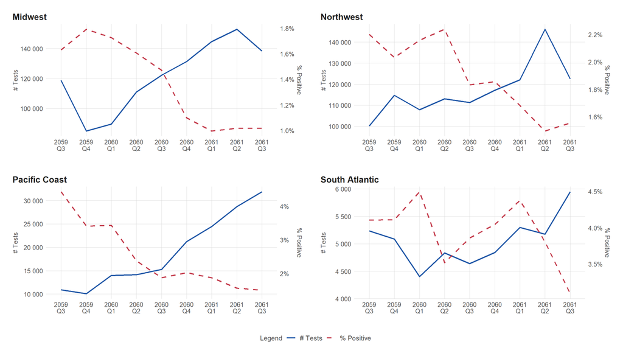

```r
# Generate plots for each SNU using the percentage plot function
plots_pr <- lapply(snu_names, create_plot_pr)

# Combine all plots into a single layout
combined_plot_pr <- wrap_plots(plots_pr, ncol = 2) + plot_layout(guides = "collect") & theme(legend.position = 'bottom')
```

**By Total # Positive Tests**

[output not shown]

[output not shown]

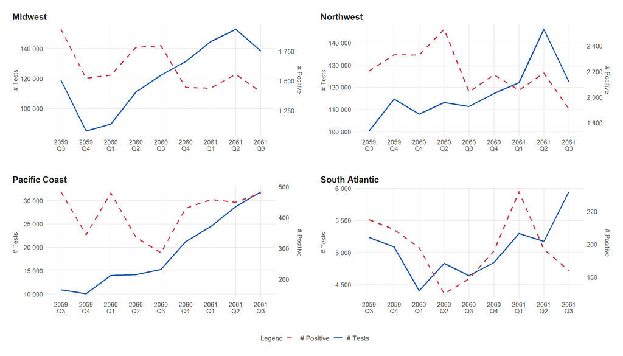

```r
# Generate plots for each SNU using the num plot function
plots_num <- lapply(snu_names, create_plot_num)

# Combine all plots into a single layout
combined_plot_num <- wrap_plots(plots_num, ncol = 2) + plot_layout(guides = "collect") & theme(legend.position = 'bottom')
```

- *Midwest*: Testing rose sharply and then fell recently. Positivity rate fell.
- *Northwest*: Testing rose sharply and then fell recently. Positivity rate fell.
- *Pacific Coast*: Testing rose. Positivity rate fell.
- *South Atlantic*: Testing rose. Positivity rate had a lot of variation.

We can also try to smooth over any quarter spikes or outliers by calculating moving averages.

```r
# Calculate 3-quarter moving averages for each SNU
summary_data_q3 <- summary_data_q3 %>%
  group_by(snu1) %>%
  arrange(Year_Quarter) %>%
  mutate(
    Testing_MA = rollmean(Total_Testing, k = 3, fill = NA, align = "right"), # 3-quarter moving average for testing
    Positivity_MA = rollmean(Total_Positivity_Ratio, k = 3, fill = NA, align = "right") # 3-quarter moving average for positivity ratio
  ) %>%
  select(snu1, Year_Quarter, Testing_MA, Positivity_MA, Total_Testing, Total_Positivity_Ratio) %>%
  ungroup()

print(summary_data_q3)
```

```
## # A tibble: 36 × 6
##    snu1           Year_Quarter Testing_MA Positivity_MA Total_Testing
##    <chr>          <fct>             <dbl>         <dbl>         <dbl>
##  1 Midwest        2059_Q3             NA        NA             118829
##  2 Northwest      2059_Q3             NA        NA             100192
##  3 Pacific Coast  2059_Q3             NA        NA              10918
##  4 South Atlantic 2059_Q3             NA        NA               5236
##  5 Midwest        2059_Q4             NA        NA              84940
##  6 Northwest      2059_Q4             NA        NA             114674
##  7 Pacific Coast  2059_Q4             NA        NA              10094
##  8 South Atlantic 2059_Q4             NA        NA               5087
##  9 Midwest        2060_Q1          97803.        0.0172         89639
## 10 Northwest      2060_Q1         107591         0.0213        107907
## # ℹ 26 more rows
## # ℹ 1 more variable: Total_Positivity_Ratio <dbl>
```

```r
# Calculate trends in moving averages
decline_in_testing_increase_in_positivity_ma <- summary_data_q3 %>%
  group_by(snu1) %>%
  arrange(Year_Quarter) %>%
  summarise(
    testing_trend_ma = last(Testing_MA, na.rm = TRUE) - first(Testing_MA, na.rm = TRUE), # Trend in testing moving average
    positivity_trend_ma = last(Positivity_MA, na.rm = TRUE) - first(Positivity_MA, na.rm = TRUE) # Trend in positivity moving average
  ) %>%
  filter(testing_trend_ma < 0 & positivity_trend_ma > 0)
```

**Moving Averages**

```
## # A tibble: 0 × 3
## # ℹ 3 variables: snu1 <chr>, testing_trend_ma <dbl>, positivity_trend_ma <dbl>
```

There are no SNUs with a negative trend in testing and positive trend in positivity when looking at moving averages.

[output not shown]

[output not shown]

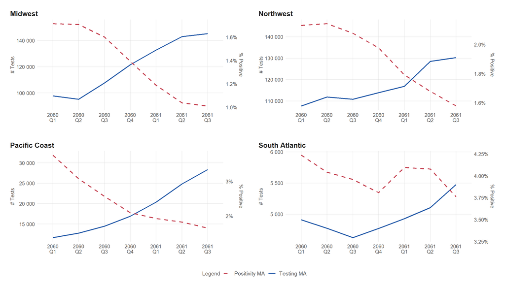

```r
# Generate plots for each SNU using the num plot function
plots_ma <- lapply(snu_names, function(snu_name) create_plot_q3_ma(snu_name))

# Combine all plots into a single layout
combined_plot_ma <- wrap_plots(plots_ma, ncol = 2) + plot_layout(guides = "collect") & theme(legend.position = 'bottom')
```

We still do not see any SNUs where there is a decline in testing and an increase in positivity.

#### **Question: Unless this is a trick question, it looks like I got it wrong. Is there something I am missing?**

## 4. What share of newly initiated patients onto treatment have a CD4 count of less than 200?

```r
# In the data, only 2061 has values for CD4
data_2061 <- data_long %>%
  filter(fiscal_year == 2061)

cumulative_txnew_counts <- data_2061 %>%
  filter(indicator == "TX_NEW", otherdisaggregate %in% c("<200 CD4", ">=200 CD4")) %>%
  summarize(
    total_cumulative_less_than_200 = sum(value[otherdisaggregate == "<200 CD4"], na.rm = TRUE),
    total_cumulative_greater_than_or_equal_200 = sum(value[otherdisaggregate == ">=200 CD4"], na.rm = TRUE),
    total_tx_new = sum(value, na.rm = TRUE)
  )

# Comparison of CD4 counts
cumulative_txnew_cd4_comparison <- data_2061 %>%
  filter(indicator == "TX_NEW", otherdisaggregate %in% c("<200 CD4", ">=200 CD4")) %>%
  group_by(fiscal_year, otherdisaggregate) %>%
  summarize(
    total_CD4_count = sum(value, na.rm = TRUE),
    .groups = "drop"
  ) %>%
  pivot_wider(
    names_from = otherdisaggregate,
    values_from = total_CD4_count,
    values_fill = list(total_CD4_count = 0)
  ) %>%
  mutate(
    total_treatment_with_CD4_disagg = `<200 CD4` + `>=200 CD4`,
    share_less_than_200_CD4 = paste0(round((`<200 CD4` / total_treatment_with_CD4_disagg) * 100, 1), "%"),
    share_greater_than_equal_200_CD4 = paste0(round((`>=200 CD4` / total_treatment_with_CD4_disagg) * 100, 1), "%"),
    total_TX_New = cumulative_txnew_counts$total_tx_new,
    less_than_200_CD4 = `<200 CD4`
  )
```

```
## # A tibble: 1 × 8
##   fiscal_year `<200 CD4` `>=200 CD4` total_treatment_with_CD4_disagg
##         <int>      <dbl>       <dbl>                           <dbl>
## 1        2061        507         832                            1339
## # ℹ 4 more variables: share_less_than_200_CD4 <chr>,
## #   share_greater_than_equal_200_CD4 <chr>, total_TX_New <dbl>,
## #   less_than_200_CD4 <dbl>
```

```r
total_percentage_both_categories <- paste0(
  round(((cumulative_txnew_cd4_comparison$total_cumulative_less_than_200 + cumulative_txnew_cd4_comparison$total_cumulative_greater_than_or_equal_200) / cumulative_txnew_cd4_comparison$total_tx_new) * 100, 1),
  "%"
)
```

It appears that `507` newly initiated patients had a CD4 <200 in `FY2061`. This is `37.9%` of newly initiated patients that have a reported CD4 in the data.

```r
cumulative_txnew_cd4_comparison_qtr <- data_2061 %>%
  filter(indicator == "TX_NEW", otherdisaggregate %in% c("<200 CD4", ">=200 CD4")) %>%
  group_by(fiscal_year, quarter, otherdisaggregate) %>%
  summarize(
    total_CD4_count = sum(value, na.rm = TRUE),
    .groups = "drop"
  ) %>%
  pivot_wider(
    names_from = otherdisaggregate,
    values_from = total_CD4_count,
    values_fill = list(total_CD4_count = NA)
  ) %>%
  mutate(
    share_less_than_200_CD4 = paste0(round((`<200 CD4` / (`<200 CD4` + `>=200 CD4`)) * 100, 1), "%"),
    share_greater_than_equal_200_CD4 = paste0(round((`>=200 CD4` / (`<200 CD4` + `>=200 CD4`)) * 100, 1), "%")
  )
```

```
## # A tibble: 3 × 6
##   fiscal_year quarter `<200 CD4` `>=200 CD4` share_less_than_200_CD4
##         <int> <chr>        <dbl>       <dbl> <chr>
## 1        2061 1              243         269 47.5%
## 2        2061 2              167         367 31.3%
## 3        2061 3               97         196 33.1%
## # ℹ 1 more variable: share_greater_than_equal_200_CD4 <chr>
```

## 5. Which age bands have had two or more quarters with declining net new on treatment?

Two or more total quarters with declining net new on treatment:

```r
# Calculate net new patient counts and identify declining trends by age
net_new_declining <- data_long %>%
  mutate(year_quarter = paste(fiscal_year, quarter, sep = "_Q")) %>%
  filter(indicator == "TX_NET_NEW") %>%
  group_by(ageasentered, year_quarter) %>%
  summarise(
    value = sum(value, na.rm = TRUE),
    .groups = "drop"
  ) %>%
  mutate(is_negative = value < 0) %>%
  group_by(ageasentered) %>%
  summarise(
    declining_quarters_count = sum(is_negative),
    .groups = "drop"
  ) %>%
  filter(declining_quarters_count >= 2) # Filter where there are any two quarters with negative TX_NET_NEW
```

These age bands have had at least 2 quarters in the data with declining `TX_NET_NEW`:

```
## # A tibble: 14 × 2
##    ageasentered declining_quarters_count
##    <chr>                           <int>
##  1 01-04                               7
##  2 05-09                              10
##  3 10-14                              10
##  4 15-19                               6
##  5 20-24                               2
##  6 25-29                               5
##  7 30-34                               3
##  8 35-39                               6
##  9 40-44                               4
## 10 50+                                 3
## 11 60-64                               2
## 12 <01                                 6
## 13 <15                                 8
## 14 Unknown Age                         2
```

We can also check for consecutive declines.

```r
# Identify consecutive declines in net new patient counts by age group
consecutive_declines <- data_long %>%
  mutate(year_quarter = paste(fiscal_year, quarter, sep = "_Q")) %>%
  filter(indicator == "TX_NET_NEW") %>%
  arrange(ageasentered, year_quarter) %>%
  group_by(ageasentered, year_quarter) %>%
  summarise(
    value = sum(value, na.rm = TRUE),
    .groups = "drop"
  ) %>%
  mutate(
    is_negative = value < 0,
    consecutive_decline = is_negative & lag(is_negative, default = FALSE), # Check for consecutive declines
    decline_group = cumsum(!consecutive_decline) # Group each consecutive decline series
  ) %>%
  filter(is_negative) %>%
  group_by(ageasentered, decline_group)%>%
  summarise(
    consecutive_decline_count = n(), # Count consecutive declines
    year_quarter_list = paste(year_quarter, collapse = ", "), # List of declining quarters
    .groups = "drop"
  ) %>%
  filter(consecutive_decline_count >= 2) %>% # Filter for at least 2 consecutive declines
  select(ageasentered, year_quarter_list)
```

**Every time an age group has two or more quarters in decline in a row:**

```
## # A tibble: 12 × 2
##    ageasentered year_quarter_list
##    <chr>        <chr>
##  1 01-04        2059_Q3, 2059_Q4
##  2 01-04        2060_Q2, 2060_Q3, 2060_Q4
##  3 05-09        2059_Q3, 2059_Q4, 2060_Q1, 2060_Q2, 2060_Q3, 2060_Q4, 2061_Q1, …
##  4 10-14        2059_Q1, 2059_Q2, 2059_Q3, 2059_Q4, 2060_Q1, 2060_Q2, 2060_Q3, …
##  5 10-14        2061_Q2, 2061_Q3
##  6 15-19        2059_Q4, 2060_Q1, 2060_Q2, 2060_Q3, 2060_Q4
##  7 25-29        2060_Q2, 2060_Q3
##  8 30-34        2060_Q2, 2060_Q3
##  9 35-39        2059_Q4, 2060_Q1, 2060_Q2, 2060_Q3, 2060_Q4
## 10 40-44        2060_Q3, 2060_Q4, 2061_Q1
## 11 <01          2059_Q2, 2059_Q3, 2059_Q4
## 12 <15          2059_Q2, 2059_Q3, 2059_Q4, 2060_Q1, 2060_Q2, 2060_Q3, 2060_Q4
```

**Age Bands with Two of More Total Declining Quarters**

```
##  [1] "01-04"       "05-09"       "10-14"       "15-19"       "20-24"
##  [6] "25-29"       "30-34"       "35-39"       "40-44"       "50+"
## [11] "60-64"       "<01"         "<15"         "Unknown Age"
```

**Age Bands with Two or More Consecutive Declines**

```
##  [1] "01-04" "05-09" "10-14" "15-19" "25-29" "30-34" "35-39" "40-44" "<01"
## [10] "<15"
```

## 6. Which sub-national units (SNUs) had net new on treatment volumes below those newly on treatment for the year?

```r
# Compare net new patients to newly initiated patients for fiscal year 2061
net_new_vs_new <- data %>%
  filter(indicator %in% c("TX_NET_NEW", "TX_NEW"), fiscal_year == 2061) %>%
  group_by(snu1, indicator) %>%
  summarise(total_cumulative = sum(cumulative, na.rm = TRUE), .groups = "drop") %>%
  pivot_wider(names_from = indicator, values_from = total_cumulative, values_fill = NA)

net_new_less_than_new <- net_new_vs_new %>%
  filter(TX_NET_NEW < TX_NEW)
```

```
## # A tibble: 4 × 3
##   snu1           TX_NET_NEW TX_NEW
##   <chr>               <dbl>  <dbl>
## 1 Midwest              4193   4341
## 2 Northwest            5647   5978
## 3 Pacific Coast        1980   1281
## 4 South Atlantic      -1537    640
```

`Midwest, Northwest, South Atlantic` had net new on treatment volumes below those newly on treatment for the year `FY2061`.

If we want to look at SNUs by quarter instead of the entire year, we can do that as well.

```r
# Compare net new patients to newly initiated patients for fiscal year 2061 by quarter
net_new_vs_new_qtr <- data_long %>%
  filter(indicator %in% c("TX_NET_NEW", "TX_NEW"), fiscal_year == 2061) %>%
  group_by(snu1, indicator, quarter) %>%
  summarise(total_cumulative = sum(value, na.rm = TRUE), .groups = "drop") %>%
  pivot_wider(names_from = indicator, values_from = total_cumulative, values_fill = NA)

# Identify quarters where SNUs had net new patients are less than newly initiated patients
net_new_less_than_new_qtr <- net_new_vs_new_qtr %>%
  filter(TX_NET_NEW < TX_NEW) # Filter to only when NET_NEW is less than NEW
net_new_less_than_new_qtr
```

```
## # A tibble: 5 × 4
##   snu1           quarter TX_NET_NEW TX_NEW
##   <chr>          <chr>        <dbl>  <dbl>
## 1 Midwest        3              620   1405
## 2 Northwest      3               48   1987
## 3 Pacific Coast  3              399    450
## 4 South Atlantic 1            -1595    245
## 5 South Atlantic 2             -196    196
```

## 7. Are any sub-national units (SNUs) lagging behind with getting a majority of patients onto 6 months or more of multi-month dispensing ( MMD) of treatment?

```r
df_tx <- data %>%
  filter(
    indicator == "TX_CURR",
    fiscal_year == 2061,
    str_detect(standardizeddisaggregate, "Total")
  ) %>%
  count(snu1, wt = cumulative, name = "tx_curr")

q7_fy <- data %>%
  filter(
    indicator == "TX_CURR",
    fiscal_year == 2061,
    standardizeddisaggregate == "Age/Sex/ARVDispense/HIVStatus"
  ) %>%
  group_by(snu1, otherdisaggregate) %>%
  summarise(total = sum(cumulative, na.rm = TRUE), .groups = "drop") %>%
  pivot_wider(
    names_from = otherdisaggregate,
    values_from = total,
    values_fill = list(total = 0) # Ensures missing categories are treated as 0
  ) %>%
  left_join(df_tx, by = join_by(snu1)) %>%
  mutate(
    less_than_6_months = `ARV Dispensing Quantity - 3 to 5 months` + `ARV Dispensing Quantity - Less than 3 months`,
    total_arv = less_than_6_months + `ARV Dispensing Quantity - 6 or more months`,
    share_denom_tx_curr = paste0(round((`ARV Dispensing Quantity - 6 or more months` / tx_curr) * 100, 1), "%"),
    share_denom_arv = paste0(round((`ARV Dispensing Quantity - 6 or more months` / total_arv) * 100, 1), "%")
  ) %>%
  select(snu1, `ARV Dispensing Quantity - 3 to 5 months`,
  `ARV Dispensing Quantity - 6 or more months`,
  `ARV Dispensing Quantity - Less than 3 months`, share_denom_tx_curr, share_denom_arv)
```

```r
q7_fy
```

```
## # A tibble: 4 × 6
##   snu1      ARV Dispensing Quant…¹ ARV Dispensing Quant…² ARV Dispensing Quant…³
##   <chr>                      <dbl>                  <dbl>                  <dbl>
## 1 Midwest                    19644                  10106                   9894
## 2 Northwest                  24610                  19179                   4202
## 3 Pacific …                    805                   3754                    287
## 4 South At…                   2388                   4572                    386
## # ℹ abbreviated names: ¹`ARV Dispensing Quantity - 3 to 5 months`,
## #   ²`ARV Dispensing Quantity - 6 or more months`,
## #   ³`ARV Dispensing Quantity - Less than 3 months`
## # ℹ 2 more variables: share_denom_tx_curr <chr>, share_denom_arv <chr>
```

```r
df_tx_qtr <- data_long %>%
  filter(
    indicator == "TX_CURR",
    fiscal_year == 2061,
    str_detect(standardizeddisaggregate, "Total")
  ) %>%
  group_by(quarter) %>%
  count(snu1, wt = value, name = "tx_curr")

q7_fy_qtr <- data_long %>%
  filter(
    indicator == "TX_CURR",
    fiscal_year == 2061,
    standardizeddisaggregate == "Age/Sex/ARVDispense/HIVStatus"
  ) %>%
  group_by(snu1, quarter, otherdisaggregate) %>%
  summarise(total = sum(value, na.rm = TRUE), .groups = "drop") %>%
  pivot_wider(
    names_from = otherdisaggregate,
    values_from = total,
    values_fill = list(total = 0) # Ensures missing categories are treated as 0
  ) %>%
  left_join(df_tx_qtr, by = join_by(snu1, quarter)) %>%
  mutate(
    less_than_6_months = `ARV Dispensing Quantity - 3 to 5 months` + `ARV Dispensing Quantity - Less than 3 months`,
    total_arv = less_than_6_months + `ARV Dispensing Quantity - 6 or more months`,
    share_denom_tx_curr = paste0(round((`ARV Dispensing Quantity - 6 or more months` / tx_curr) * 100, 1), "%"),
    share_denom_arv = paste0(round((`ARV Dispensing Quantity - 6 or more months` / total_arv) * 100, 1), "%")
  ) %>%
  select(quarter, snu1, `ARV Dispensing Quantity - 3 to 5 months`,
  `ARV Dispensing Quantity - 6 or more months`,
  `ARV Dispensing Quantity - Less than 3 months`, share_denom_tx_curr, share_denom_arv)
```

```
## # A tibble: 12 × 7
##    quarter snu1           ARV Dispensing Quantity - 3 t…¹ ARV Dispensing Quant…²
##    <chr>   <chr>                                    <dbl>                  <dbl>
##  1 1       Midwest                                  19019                   9747
##  2 2       Midwest                                  18903                   8993
##  3 3       Midwest                                  19644                  10106
##  4 1       Northwest                                26197                  16621
##  5 2       Northwest                                26798                  16775
##  6 3       Northwest                                24610                  19179
##  7 1       Pacific Coast                              902                   3201
##  8 2       Pacific Coast                              930                   3433
##  9 3       Pacific Coast                              805                   3754
## 10 1       South Atlantic                            2702                   4090
## 11 2       South Atlantic                            2483                   4398
## 12 3       South Atlantic                            2388                   4572
## # ℹ abbreviated names: ¹`ARV Dispensing Quantity - 3 to 5 months`,
## #   ²`ARV Dispensing Quantity - 6 or more months`
## # ℹ 3 more variables: `ARV Dispensing Quantity - Less than 3 months` <dbl>,
## #   share_denom_tx_curr <chr>, share_denom_arv <chr>
```

To undersand the difference between the two share values, we look at who is providing ARVDispense. It looks like MMD data is provided (Total Numerator = Age/Sex/ARVDispense/HIVStatus)for all in Midwest and Pacific Coast, but not for Northwest and South Atlantic.

```r
  data %>%
    filter(
      indicator == "TX_CURR",
      fiscal_year == 2061,
      str_detect(standardizeddisaggregate, "ARV|Total")
    ) %>%
    count(snu1, indicator, standardizeddisaggregate, wt = cumulative) %>%
    pivot_wider(names_from = standardizeddisaggregate, values_from = n) %>%
    mutate(diff = .[[3]] - .[[4]]) %>%
  select(snu1, diff, `Age/Sex/ARVDispense/HIVStatus`, `Total Numerator`)
```

```
## # A tibble: 4 × 4
##   snu1             diff `Age/Sex/ARVDispense/HIVStatus` `Total Numerator`
##   <chr>           <dbl>                           <dbl>             <dbl>
## 1 Midwest             0                           39644             39644
## 2 Northwest       -1521                           47991             49512
## 3 Pacific Coast       0                            4846              4846
## 4 South Atlantic -22554                            7346             29900
```

## 8. Do we see any differences in viral load coverage (VLC) by age and sex for the current year?

*Using `FY2061 Q3` data.*

```r
# Calculate TX_CURR_Lag
tx_curr_lag <- data_long %>%
  filter(
    indicator == "TX_CURR_Lag2",
    fiscal_year == 2061,
    quarter == 3,
    use_for_age == "Y"
  ) %>%
  group_by(sex, ageasentered) %>%
  summarise(TX_CURR_Lag = sum(value, na.rm = TRUE), .groups = "drop")

# Calculate TX_PVLS
tx_pvls <- data_long %>%
  filter(
    indicator == "TX_PVLS",
    fiscal_year == 2061,
    quarter == 3,
    numeratordenom == "D"
  ) %>%
  group_by(sex, ageasentered) %>%
  summarise(TX_PVLS = sum(value, na.rm = TRUE), .groups = "drop")

# Combine TX_CURR_Lag and TX_PVLS data, calculating VLC
vlc_data <- tx_curr_lag %>%
  left_join(tx_pvls, by = c("sex", "ageasentered")) %>%
  mutate(VLC = TX_PVLS / TX_CURR_Lag) %>%
  filter(!is.na(VLC)) # Remove rows with NA values in VLC

# Calculate VLC percentage and prepare results
results_q8 <- vlc_data %>%
  mutate(VLC_Percentage = VLC * 100) %>%
  select(sex, ageasentered, VLC_Percentage)
```

```
## # A tibble: 32 × 3
##    sex    ageasentered VLC_Percentage
##    <chr>  <chr>        <chr>
##  1 Female 01-04        73.9%
##  2 Female 05-09        73.2%
##  3 Female 10-14        80.4%
##  4 Female 15-19        70.3%
##  5 Female 20-24        68.7%
##  6 Female 25-29        65.9%
##  7 Female 30-34        69.5%
##  8 Female 35-39        69.8%
##  9 Female 40-44        74.5%
## 10 Female 45-49        74.6%
## # ℹ 22 more rows
```

```r
# Calculate Viral Load Coverage (VLC) differences between men and women
vlc_diff <- vlc_data %>%
  filter(ageasentered != "Unknown Age") %>%
  group_by(ageasentered) %>%
  summarise(
    VLC_Women = sum(TX_PVLS[sex == "Female"], na.rm = TRUE) / sum(TX_CURR_Lag[sex == "Female"], na.rm = TRUE) * 100,
    VLC_Men = sum(TX_PVLS[sex == "Male"], na.rm = TRUE) / sum(TX_CURR_Lag[sex == "Male"], na.rm = TRUE) * 100,
    # Calculate absolute difference in VLC
    Difference = abs(VLC_Women - VLC_Men),
    .groups = "drop"
  ) %>%
  # Filter out rows with NA values in VLC calculations
  filter(!is.na(VLC_Women) & !is.na(VLC_Men))

# Identify the age group with the most pronounced difference in VLC
most_pronounced_diff <- vlc_diff %>%
  filter(Difference == max(Difference)) %>%
  mutate(
    VLC_Percentage = paste0(round(Difference, 2), "%"),
    VLC_Men = paste0(round(VLC_Men, 2), "%"),
    VLC_Women = paste0(round(VLC_Women, 2), "%")
  ) %>%
  select(ageasentered, VLC_Men, VLC_Women, VLC_Percentage)
```

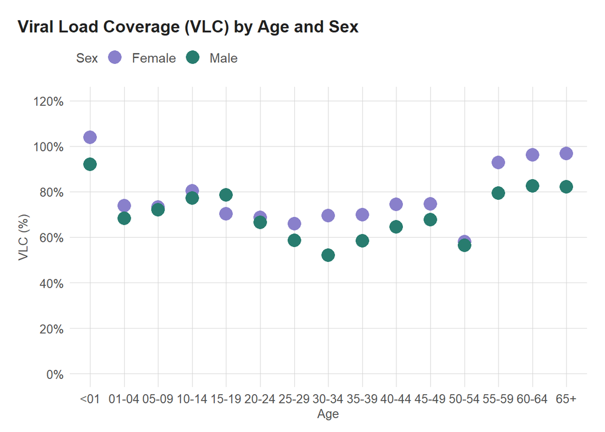

```r
# Create a plot of VLC by age and sex
vlc_data <- vlc_data %>%
  filter(ageasentered != "Unknown Age")

ggplot(vlc_data, aes(x = ageasentered, y = VLC, color = sex)) +
  geom_point(size = 5) +
  labs(
    title = "Viral Load Coverage (VLC) by Age and Sex",
    x = "Age",
    y = "VLC (%)",
    color = "Sex"
  ) +
  scale_color_manual(values = c("Female" = moody_blue, "Male" = genoa)) +
  theme_minimal() +
  scale_y_continuous(labels = scales::percent_format(scale = 100), limits = c(0, 1.2), breaks = seq(0, 1.2, by = .2)) +
  si_style()
```

With the exception of the `15-19` age group, women demonstrate higher viral load coverage (VLC) than men. The highest VLC is found in the youngest (`<01`) and oldest age groups (`55-59`, `60-64`, `65+`). There is an upward trend in VLC for children aged `01-04`, `05-09`, and `10-14`, followed by a decline in the `15-19` and `20-24` age groups, after which women’s VLC gradually rises again. In contrast, men experience a decline through the `30-34` age group before starting to increase. The age group with the most significant difference in VLC between men and women is `30-34`, which has a `17.38%` difference. This pattern is more pronounced among men, who show a sharper decline in their teens and twenties, as well as a steeper rise in their thirties and forties. Notably, the `50-54` age group stands out as an outlier, exhibiting much lower VLC than the overall trend would suggest.

#### **Question: what if the PLHIV age out of one group and into another? For instance, if someone is 19 in 2061 Q1 and 20 in 2061 Q3? Also, the question asks for the full year. Should I calculate each quarter separately, or would lumping them together (i.e. not filtering on quarter) provide better results?**